# PA1_template.Rmd

```r
across[which.max(across$steps),]
```

```
##     interval    steps
## 104      835 206.1698
```

Missing values were filled in using the mean steps taken across all subjects during that time interval (using only real values). Similar steps as were taken with the original data frame “data” are taken with dataf to generate a histogram

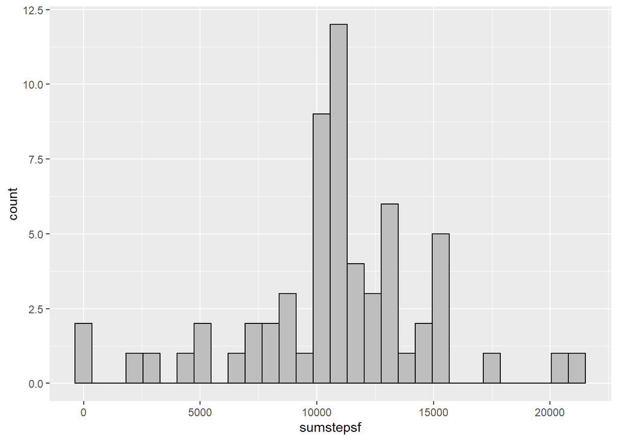

```r
ggplot(stepsbydayf)+
   geom_histogram(color = "black", fill = "grey", aes(x = sumstepsf))
```

```r
allmeanf <- mean(stepsbydayf$sumstepsf)
allmedianf <- median(stepsbydayf$sumstepsf)
cbind(allmean, allmedian)
```

```
##       allmean allmedian
## [1,] 10766.19     10765
```

We see that filling in the data leave the median and mean remarkably almost unchanged. dplyr and grepl are used to add another variable to dataf denoting whether the day in question is a weekday or weekend

```r
dataf <- dataf%>%
   mutate(day = weekdays(date))%>%
   mutate(daytype = ifelse(grepl("Saturday", day)|(grepl("Sunday", day)), "Weekend", "Weekday"))
dataf$daytpe <- as.factor(dataf$daytype)
daytypemean <- dataf%>%
   select(stepsf, interval, daytype)%>%
   group_by(daytype, interval)%>%
   summarize(meansteps = mean(stepsf))
```

Finally, a faceted call to ggplot2 creates side by side line graphs comparing the mean steps by interval between weekdays and weekends.

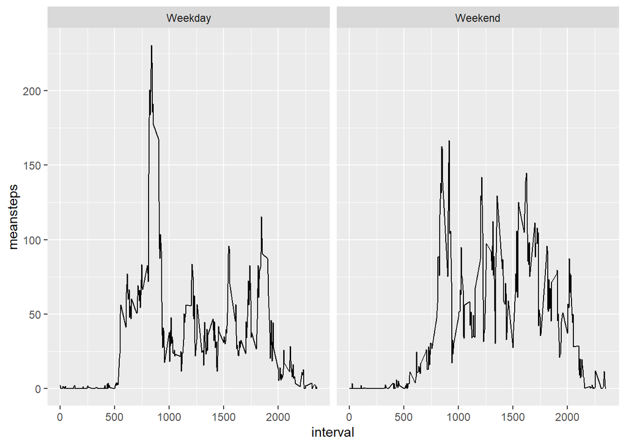

```r
ggplot(daytypemean, aes(x = interval, y = meansteps))+
   geom_line()+
   facet_wrap(~ daytype)
```